# Compensatory Renal Hypertrophy: Deconvolution of bulk RNA-seq

Vincent Wong

24 June, 2021

Knowledge of cell type composition in compensatory renal hypertrophy kidney tissue is an important step towards the identification of cellular targets that undergo the most changes. I use MuSiC (see X. Wang et al. 2019), a method that utilizes cell-type specific gene expression from single-cell RNA sequencing (RNA-seq) data to characterize cell type compositions from bulk RNA-seq data in complex kidney tissue. Here I used the single cell data are from GEO entry (GSE107585) (see J. Park et al. 2018), which contains read counts for 16272 genes across 43745 cells.

# Setup

First we load all the required `R` packages

```r
library(tidyverse)
library(magrittr)
library(Biobase)
library(xbioc)
library(ganalyse)
library(MuSiC)
library(reshape)
library(RColorBrewer)
library(pheatmap)
library(viridis)
library(pander)
```

```r
panderOptions("table.split.table", Inf)
panderOptions("table.style", "rmarkdown")
panderOptions("big.mark", ",")
```

# Estimation of cell type proportions with pre-grouping of cell types

Solid tissues often contain closely related cell types, and correlation of gene expression between these cell types leads to collinearity, making it difficult to resolve their relative proportions in bulk data. To deal with collinearity, MuSiC employs a tree-guided procedure that recursively zooms in on closely related cell types.

## Data Preparation

```r
#load bulk RNA-seq
CRH.eset <- readRDS("C:/Users/cronos/Box Sync/Desktop/Renal Hypertrophy/CRH_RNAseq/CRH.eset.rds")

#load scRNA-seq (Park et al. 2018)
Mouse.eset <- readRDS("C:/Users/cronos/Box Sync/Desktop/Renal Hypertrophy/CRH_RNAseq/Mouse.eset.rds")
```

## Clustering single cell data

In MuSiC estimation procedure, the first step is to produce design matrix, cross-subject mean of relative abundance, cross-subject variance of relative abundance and average library size from single cell reference. These are taken care of by the function music_basis. The essential inputs of music_basis are:

- x: ExpressionSet of single cell dataset;
- non.zero: logical, default as TRUE. If true, remove all genes with zero expression;
- markers: vector or list of gene names. Default as NULL. If NULL, then use all genes provided by x;
- clusters: character, must be one of the column names of the phenoData from single cell data, used as clusters;
- samples: character, must be one of the column names of the phenoData from single cell data, used as samples;
- select.ct vector of cell types included for deconvolution, default as NULL. If NULL, then use all cell types that provided by single-cell dataset.
- verbose logical that toggles log messages.

The outputs of music_basis is a list of elements:

- Disgn.mtx: gene by cell type matrix of design matrix;
- S: subject by cell type matrix of library size;
- M.S: vector of average library size for each cell type;
- M.theta: gene by cell type matrix of average relative abundance;
- Sigma: gene by cell type matrix of cross-subject variation.

Next, use the hclust function to get a tree0based clustering of the cell types using the cross-subject mean matrix and the design matrix.

```r
# Produce the first step information
# Mouse.basis = music_basis(Mouse.eset, clusters = 'cellType', samples = 'sampleID',
#                              select.ct = c('Endo', 'Podo', 'PT', 'LOH', 'DCT', 'CD-PC', 'CD-IC', 'Fib',
#                                            'Macro', 'Neutro','B lymph', 'T lymph', 'NK'))
#
# saveRDS(Mouse.basis, file="Mouse.basis.rds")

Mouse.basis <- readRDS("C:/Users/cronos/Box Sync/Desktop/Renal Hypertrophy/CRH_RNAseq/Mouse.basis.rds")
```

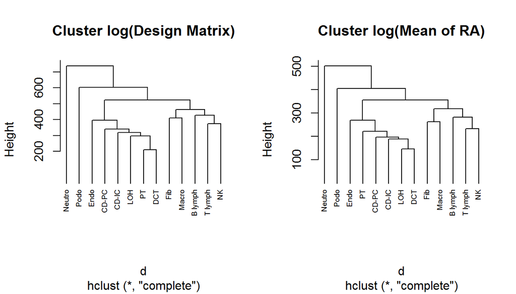

```r
# Plot the dendrogram of design matrix and cross-subject mean of relative abundance
par(mfrow = c(1, 2))
d <- dist(t(log(Mouse.basis$Disgn.mtx + 1e-6)), method = "euclidean")
# Hierarchical clustering using Complete Linkage
hc1 <- hclust(d, method = "complete" )
# Plot the obtained dendrogram
plot(hc1, cex = 0.6, hang = -1, main = 'Cluster log(Design Matrix)')
d <- dist(t(log(Mouse.basis$M.theta + 1e-8)), method = "euclidean")
# Hierarchical clustering using Complete Linkage
# hc2 <- hclust(d, method = "complete" )
hc2 <- hclust(d, method = "complete")
# Plot the obtained dendrogram
plot(hc2, cex = 0.6, hang = -1, main = 'Cluster log(Mean of RA)')
```

The immune cells are clustered together and the kidney specific cells are clustered together. Notice that DCT and PT are within the same high-level grouping. The cut-off is user determined. Here we cut 13 cell types into 4 groups:

- Group 1: Neutro
- Group 2: Podo
- Group 3: Endo, CD-PC, CD-IC, LOH, DCT, PT
- Group 4: Fib, Macro, NK, B lymph, T lymph

The tree-guided recursive estimation for mouse kidney analysis includes 2 steps:

- Step 1. Estimate proportions of each high level cluster; (p1,p2,p3,p4)
- Step 2. Estimate cell type proportions within each cluster; (p31,p32,.,p36,p41,.,p45)

## Pre-grouping of Cell Types

Manually specify the cluster and annotated single cell data with cluster information.

```r
clusters.type = list(C1 = 'Neutro', C2 = 'Podo', C3 = c('Endo', 'CD-PC', 'LOH', 'CD-IC', 'DCT', 'PT'), C4 = c('Macro', 'Fib', 'B lymph', 'NK', 'T lymph'))

cl.type = as.character(Mouse.eset$cellType)

for(cl in 1:length(clusters.type)){
  cl.type[cl.type %in% clusters.type[[cl]]] = names(clusters.type)[cl]
}
pData(Mouse.eset)$clusterType = factor(cl.type, levels = c(names(clusters.type), 'CD-Trans', 'Novel1', 'Novel2'))

# 13 selected cell types
s.mouse = unlist(clusters.type)
s.mouse
```

```
##        C1        C2       C31       C32       C33       C34       C35       C36
##  "Neutro"    "Podo"    "Endo"   "CD-PC"     "LOH"   "CD-IC"     "DCT"      "PT"
##       C41       C42       C43       C44       C45
##   "Macro"     "Fib" "B lymph"      "NK" "T lymph"
```

```r
IEmarkers <- load(gzcon(url('https://xuranw.github.io/MuSiC/data//IEmarkers.RData')))

Neutro<-character(0)
Podo<-character(0)
Endo<-Epith.marker
Macro<-Immune.marker
IEmarkers<-list("C1"=Neutro,"C2"=Podo,"C3"=Endo,"C4"=Macro)
```

## Bulk Tissue Cell Type Estimation

```r
# Est.mouse.bulk = music_prop.cluster(bulk.eset = CRH.eset, sc.eset = Mouse.eset, group.markers = IEmarkers, clusters = 'cellType', group = 'clusterType', samples = 'sampleID', clusters.type = clusters.type)
#
# saveRDS(Est.mouse.bulk, file="Est.mouse.bulk.rds")

Est.mouse.bulk <- readRDS("C:/Users/cronos/Box Sync/Desktop/Renal Hypertrophy/CRH_RNAseq/Est.mouse.bulk.rds")
```

# Cell type percentage

```r
#Create percentage
Est.mouse.bulk$Est.percent.weighted.cluster <- Est.mouse.bulk$Est.prop.weighted.cluster*100

Est.mouse.bulk$Est.percent.weighted.cluster[,2:8] %>% as.data.frame() %>%
  rownames_to_column("Sample") %>% as_tibble() %>% pander()
```

| Sample | Podo | Endo | CD-PC | LOH | CD-IC | DCT | PT |
| --- | --- | --- | --- | --- | --- | --- | --- |
| RNASeq-11 | 0.8859 | 3.195 | 1.768 | 5.532 | 2.739 | 19.3 | 66.58 |
| RNASeq-40 | 0 | 1.78 | 0.3631 | 15.36 | 0.4123 | 12.75 | 69.33 |
| RNASeq-33 | 0.4035 | 3.106 | 1.707 | 7.403 | 2.443 | 17.57 | 67.37 |
| RNASeq-36 | 0 | 1.92 | 0.8982 | 19.37 | 0.5153 | 9.348 | 67.95 |
| RNASeq-16 | 0.7087 | 3.154 | 1.746 | 6.083 | 2.641 | 18.98 | 66.69 |
| RNASeq-37 | 0 | 2.342 | 0.9478 | 16.12 | 0.5891 | 8.948 | 71.05 |
| RNASeq-20 | 0.9004 | 3.163 | 1.749 | 5.548 | 2.721 | 19.37 | 66.55 |
| RNASeq-7 | 6.722 | 3.112 | 1.783 | 4.796 | 2.86 | 19.5 | 61.23 |
| RNASeq-2 | 0 | 2.084 | 1.771 | 14.33 | 0.6984 | 7.118 | 74 |
| RNASeq-14 | 1.381 | 3.193 | 1.841 | 5.639 | 2.881 | 19.69 | 65.37 |
| RNASeq-18 | 9.113 | 3.026 | 1.736 | 4.576 | 2.831 | 19.17 | 59.55 |
| RNASeq-13 | 0.9329 | 3.16 | 1.758 | 5.856 | 2.7 | 19.11 | 66.48 |
| RNASeq-38 | 0 | 1.884 | 0.2214 | 12.71 | 0.5293 | 10.73 | 73.93 |
| RNASeq-5 | 0 | 2.198 | 0.53 | 10.13 | 0.5459 | 7.194 | 79.4 |
| RNASeq-10 | 1.272 | 3.201 | 1.822 | 5.238 | 2.868 | 19.89 | 65.71 |
| RNASeq-24 | 4.729 | 3.188 | 1.798 | 4.968 | 2.93 | 19.83 | 62.56 |
| RNASeq-12 | 2.774 | 3.224 | 1.847 | 5.157 | 2.961 | 19.91 | 64.13 |
| RNASeq-35 | 0 | 2.457 | 0.9869 | 19.3 | 0.5367 | 6.681 | 70.04 |
| RNASeq-22 | 0.9252 | 3.205 | 1.809 | 5.602 | 2.788 | 19.51 | 66.17 |
| RNASeq-30 | 0.469 | 3.066 | 1.68 | 6.717 | 2.478 | 17.8 | 67.79 |
| RNASeq-3 | 0 | 2.638 | 0.6205 | 16.24 | 0.6369 | 8.096 | 71.77 |
| RNASeq-19 | 1.503 | 3.267 | 1.869 | 5.414 | 2.914 | 20.07 | 64.96 |
| RNASeq-21 | 1.123 | 3.191 | 1.811 | 5.549 | 2.827 | 19.62 | 65.88 |
| RNASeq-6 | 0.7155 | 3.089 | 1.743 | 5.66 | 2.608 | 18.66 | 67.53 |
| RNASeq-31 | 0 | 1.688 | 0.5887 | 13.78 | 0.3565 | 7.327 | 76.26 |
| RNASeq-29 | 0.2829 | 3.018 | 1.632 | 9.039 | 2.225 | 16.54 | 67.26 |
| RNASeq-39 | 0 | 2.312 | 0.7803 | 19.37 | 0.6244 | 5.661 | 71.25 |
| RNASeq-15 | 1.335 | 3.203 | 1.853 | 5.762 | 2.856 | 19.56 | 65.44 |
| RNASeq-17 | 0.7776 | 3.155 | 1.744 | 5.566 | 2.675 | 19.31 | 66.78 |
| RNASeq-9 | 7.485 | 3.086 | 1.763 | 4.752 | 2.879 | 19.37 | 60.67 |
| RNASeq-34 | 0 | 2.232 | 1.336 | 14.92 | 0.8865 | 9.091 | 71.53 |
| RNASeq-23 | 9.041 | 3.021 | 1.73 | 4.589 | 2.829 | 19.11 | 59.68 |
| RNASeq-1 | 0 | 1.991 | 0.718 | 8.304 | 0.5961 | 7.977 | 80.41 |
| RNASeq-4 | 0 | 2.12 | 0.731 | 14.65 | 0.5437 | 5.189 | 76.77 |
| RNASeq-32 | 0.4858 | 3.247 | 1.734 | 7.096 | 2.534 | 17.73 | 67.18 |
| RNASeq-8 | 2.541 | 3.242 | 1.845 | 5.502 | 2.947 | 19.79 | 64.13 |

# Graphical plot

Add bulk RNA-seq information to the estimated data

```r
setwd("C:/Users/cronos/Box Sync/Desktop/Renal Hypertrophy/CRH_RNAseq")

samples <- read_csv("samples.csv") %>%
  distinct(sampleName, .keep_all = TRUE) %>%
  dplyr::select(sample = sampleName,time= timepoint, everything()) %>%
  mutate(
    treatment = factor(treatment, levels = c("Sham", "Unx")),
    time = factor(time, levels=c("24hr","48hr","72hr")),
    group = factor(group,
                       levels=c("Sham.24hr", "Sham.48hr", "Sham.72hr",
                                "Unx.24hr", "Unx.48hr", "Unx.72hr")))

groupCols <- samples$group %>%
  levels() %>%
  length() %>%
  brewer.pal("Dark2") %>%
  setNames(levels(samples$group))

timeCols <- samples$time %>%
  levels() %>%
  length() %>%
  brewer.pal("Set2") %>%
  setNames(levels(samples$time))

treatCols <- samples$treatment %>%
  levels() %>%
  length() %>%
  brewer.pal("Set1") %>%
  setNames(levels(samples$treatment)) %>%
  .[-3]
```

```r
#Since there is no immune prop, I then remove it from the data before plotting
m.Est.mouse.bulk <-
  melt(Est.mouse.bulk$Est.percent.weighted.cluster) %>%
  .[-4] %>%
  set_colnames(c('sample', 'CellType', 'Prop')) %>%
  left_join(samples)  %>%
  dplyr::filter(CellType!="Macro") %>%
  dplyr::filter(CellType!="Fib") %>%
  dplyr::filter(CellType!="B lymph") %>%
  dplyr::filter(CellType!="T lymph") %>%
  dplyr::filter(CellType!="NK") %>%
  dplyr::filter(CellType!="Neutro") %>%
  mutate(CellType = as.factor(as.character(CellType)))

cellTypeCols <- m.Est.mouse.bulk$CellType %>%
  levels() %>%
  length() %>%
  brewer.pal("Set2") %>%
  setNames(levels(m.Est.mouse.bulk$CellType))
```

## Boxplot

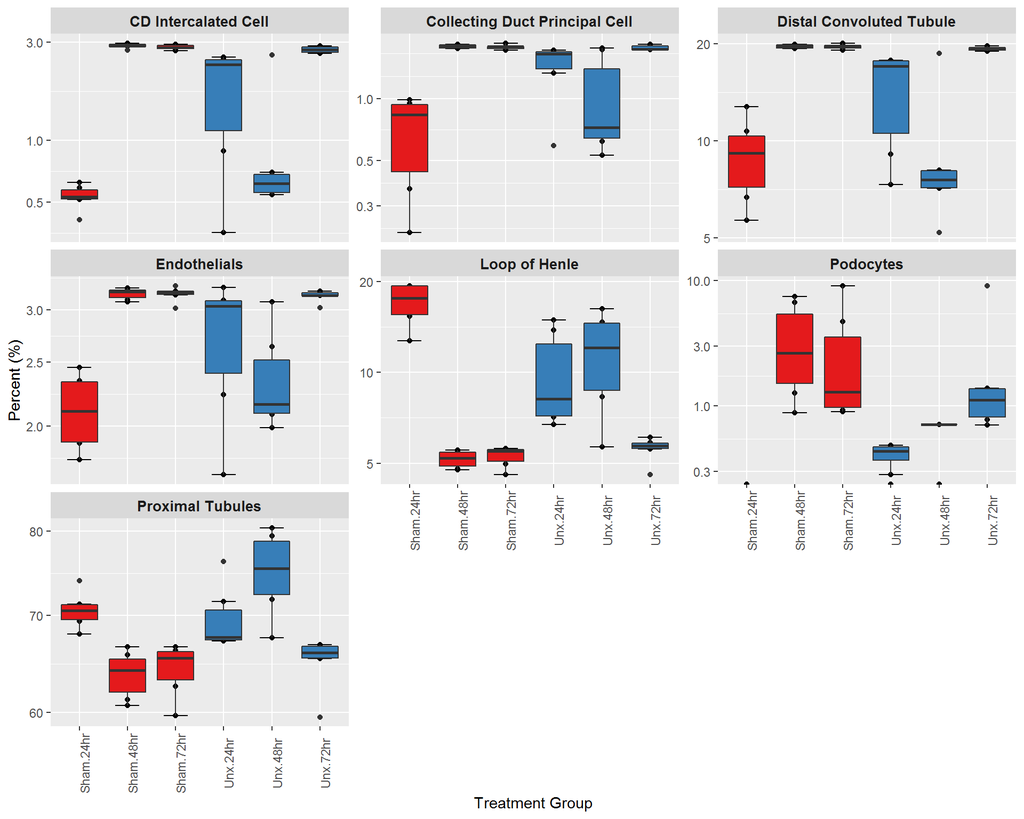

```r
ggplot(m.Est.mouse.bulk, aes(group, Prop, fill=treatment )) +
  geom_point() +
  stat_boxplot(geom='errorbar', linetype=1, width=0.5)+
  geom_boxplot() +
  facet_wrap(
    ~CellType,
    scales = "free_y",
    labeller = as_labeller(c(Podo = "Podocytes", PT = "Proximal Tubules",
                             Endo = "Endothelials", LOH ="Loop of Henle",
                             'CD-PC'="Collecting Duct Principal Cell",
                             'CD-IC'='CD Intercalated Cell',
                             "DCT"="Distal Convoluted Tubule")))+
  scale_fill_manual(values = treatCols) +
  scale_y_log10()  +
  labs(x = "Treatment Group",
       y = "Percent (%)") +
  theme(legend.position = "none",axis.text.x = element_text(angle = 90),
        strip.text = element_text(size= 10, face="bold"))
```

## Average Expression Line Plot

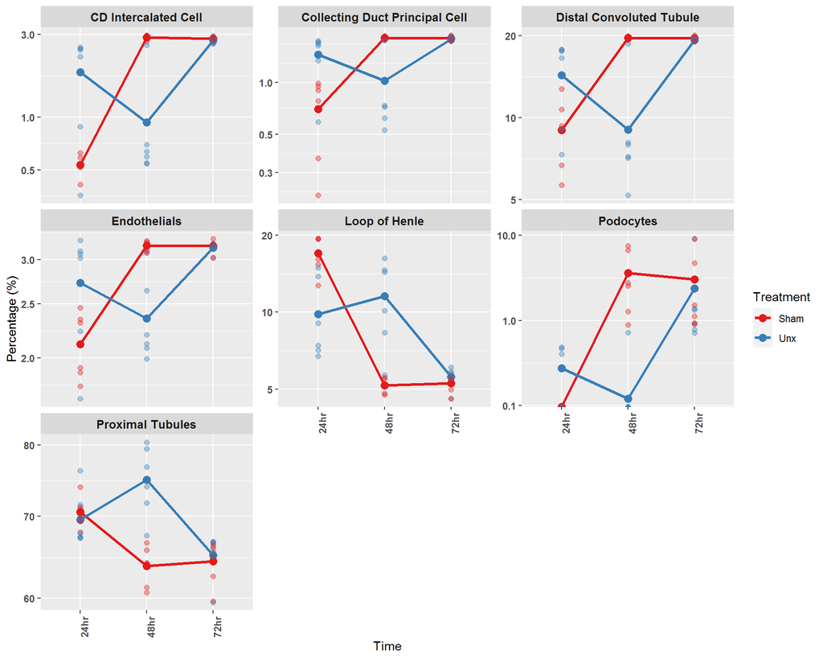

```r
#Create average expression of dataframe
m.Est.mouse.bulk_mean <-
  aggregate(m.Est.mouse.bulk$Prop,
            by=list(m.Est.mouse.bulk$treatment,
                    m.Est.mouse.bulk$time,
                    m.Est.mouse.bulk$CellType),
                 function(x)mean(x, na.rm=TRUE)) %>%
  set_colnames( c("treatment", "time", "CellType","Prop"))

#plot
ggplot(m.Est.mouse.bulk_mean,
       aes(x= time, y=Prop, group=treatment)) +
  geom_line(aes(colour=treatment),size =1.2) +
  geom_point(aes(colour=treatment),size = 3) +
  geom_point(data=m.Est.mouse.bulk, aes(colour=treatment)
             ,size = 2, alpha = 0.4)+
  facet_wrap(
    ~CellType,
    scales = "free_y",
    labeller = as_labeller(c(Podo = "Podocytes", PT = "Proximal Tubules",
                             Endo = "Endothelials", LOH ="Loop of Henle",
                             'CD-PC'="Collecting Duct Principal Cell",
                             'CD-IC'='CD Intercalated Cell',
                             "DCT"="Distal Convoluted Tubule")))+
  scale_colour_manual(values = treatCols) +
  scale_y_log10()  +
  labs(x = "Time",
       y = "Percentage (%)",
       colour = "Treatment") +
  theme(axis.text.x = element_text(angle = 90, face= "bold"),
        axis.text.y = element_text(face= "bold"),
        strip.text = element_text(size= 10, face="bold"))
```

## Barplot of Cell Type Proportion in Groups

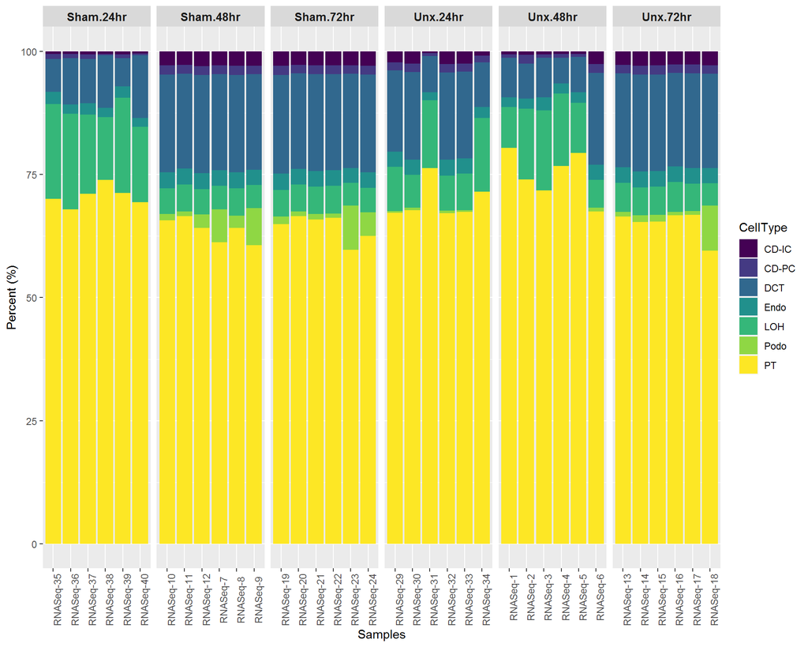

```r
ggplot(m.Est.mouse.bulk, aes(x=sample, y=Prop,fill=CellType )) +
  geom_bar( stat = "identity") +
  facet_wrap(~group, scales = "free_x", nrow=1)+
  # scale_fill_manual(values = cellTypeCols) +
  scale_fill_viridis(discrete = T,option = "D") +
  labs(x = "Samples",
       y = "Percent (%)") +
  theme(axis.text.x = element_text(angle = 90),
        strip.text = element_text(size= 10, face="bold"))
```

## Heatmap

Here in this heatmap, I can see that 5 Unx samples has proximal tubules increase in proportion with majority of them coming fron Unx 48 hours.

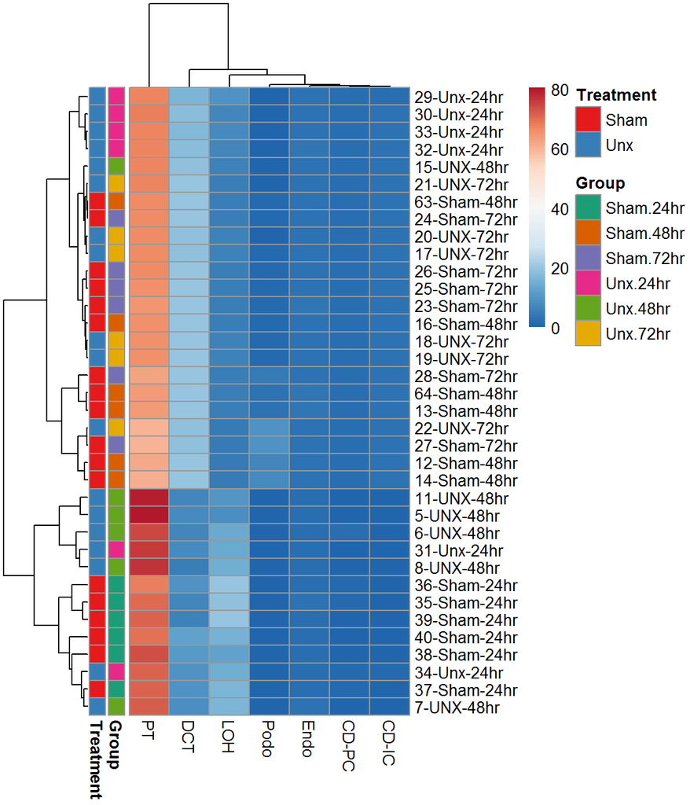

```r
heatmap.plot <- Est.mouse.bulk$Est.percent.weighted.cluster[,2:8] %>% as.data.frame() %>%
  rownames_to_column("sample")  %>% left_join(samples) %>%
  mutate(sample = as.factor(sample)) %>% column_to_rownames("sample")


heatmap.plot %>% .[,1:7] %>%
  pheatmap::pheatmap(
    colorRampPalette(rev(brewer.pal(n = 7, name ="RdBu")))(100),
    labels_row = heatmap.plot$label,
    # color = viridis_pal(option = "magma")(100),
    # border_color = NA,
    # legend_breaks = c(seq(-0.2, 0.2, by = 0.1)),
    # legend_labels = c(seq(-0.2, 0.2, by = 0.1)),
    legend = TRUE,
    annotation_legend = TRUE,
    annotation_row = heatmap.plot %>%
      dplyr::select(Group = group, Treatment = treatment),
    annotation_names_col = FALSE,
    annotation_colors = list(Group = groupCols, Treatment = treatCols))
```

## Z-score normalised Heatmap

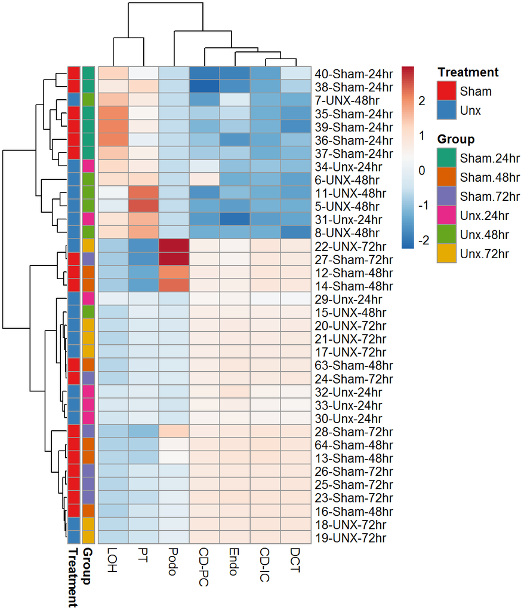

```r
heatmap.plot %>% .[,1:7] %>%
  scale() %>% as.data.frame() %>%
  pheatmap::pheatmap(
    colorRampPalette(rev(brewer.pal(n = 7, name ="RdBu")))(100),
    labels_row = heatmap.plot$label,
    # color = viridis_pal(option = "magma")(100),
    # border_color = NA,
    # legend_breaks = c(seq(-0.2, 0.2, by = 0.1)),
    # legend_labels = c(seq(-0.2, 0.2, by = 0.1)),
    annotation_row = heatmap.plot %>%
      dplyr::select(Group = group, Treatment = treatment),
    annotation_names_col = FALSE,
    annotation_colors = list(Group = groupCols, Treatment = treatCols))
```